# Recalling Words

```r
# Play the chunk above and this one to get the data into your Console
View(Friendly)
?Friendly
```

## Background

Many teachers and other educators are interested in understanding how to best deliver new content to students. In general, they have two choices of how to do this.

1. The Meshed Approach
   - Deliver new content while simultaneously reviewing previously understood content.
2. The Before Approach
   - Deliver new content after fully reviewing previously understood content.

A study was performed to determine whether the *Meshed* or *Before* approaches to delivering content had any positive benefits on memory recall.

##### The Experiment (click to view)

## Analysis

#### Hypothesis

Using the data, we answer the question, “Does the `Meshed` approach have positive benefits on recall?” In other words, is the median numeber of words recalled using the Meshed approach higher than the median for those using standard free recall (`SFR`)?
$$H_0: \text{difference in medians} = 0$$

$$H_a: \text{difference in medians} > 0$$

The significance level will be set at 0.05.
$$\alpha = 0.05$$

#### Graphics and Numerical Summaries

The boxplots below show the number of words recalled by individuals who used the `Meshed` approached compared to those who used the control group, standard free recall (`SFR`).

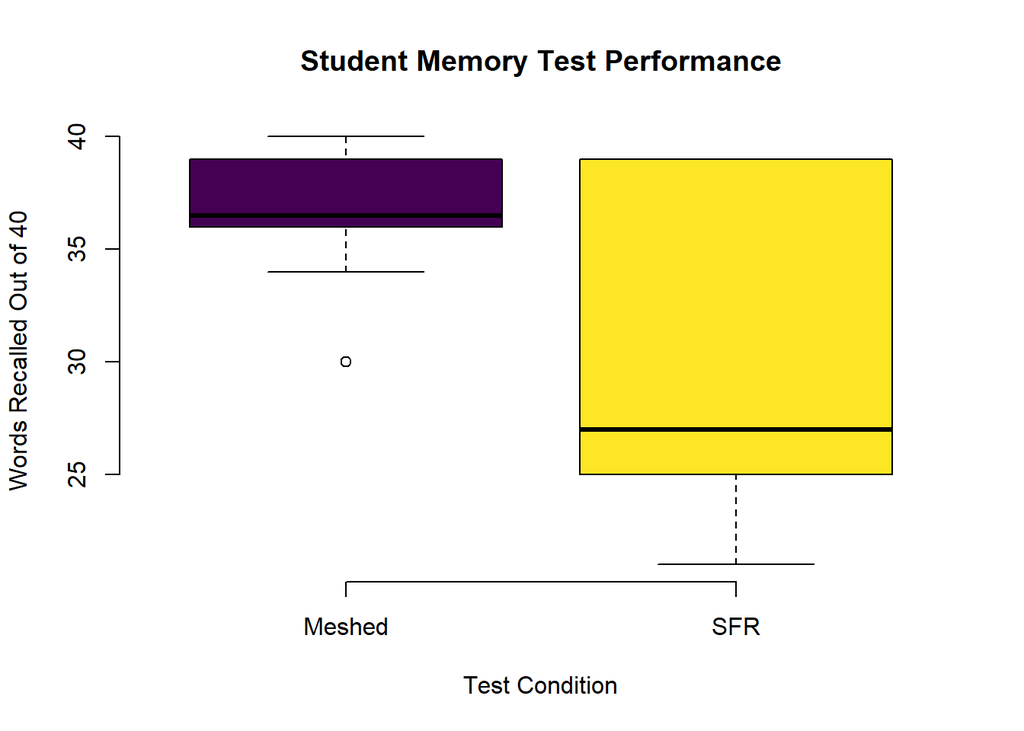

```r
# Remove the data from those using the Before approach
newdata <- Friendly %>% filter(condition != "Before")
newdata$condition <- as.character(newdata$condition)
boxplot(correct ~ condition, data = newdata, main="Student Memory Test Performance", ylab="Words Recalled Out of 40", xlab="Test Condition", col = viridis(2), frame=FALSE)
```

```r
#ggplot version: boxplot(correct~condition, data=newdata, main="Student Memory Test Performance", ylab="Words Recalled Out of 40", xlab="Test Condition", col = c("#66e0ff66", "#ff751a66"))
```

The difference in the two groups can be seen better in the five number summary below:

```r
# Create a numeric vector with rent prices by gender
sfrrecall <- filter(newdata, condition == "SFR")
meshedrecall <- filter(newdata, condition == "Meshed")

# Bind vectors
recallTable <- rbind(SFR =favstats(sfrrecall$correct), Meshed=favstats(meshedrecall$correct))

# Create the table
# HOW DO YOU CENTER THE TITLE?
pander(recallTable[c("min","Q1","median","mean","Q3","max","n")], caption="Summary of Words Correctly Recalled")
```

Summary of Words Correctly Recalled

|  | min | Q1 | median | mean | Q3 | max | n |
| --- | --- | --- | --- | --- | --- | --- | --- |
| **SFR** | 21 | 25 | 27 | 30.3 | 38.5 | 39 | 10 |
| **Meshed** | 30 | 36 | 36.5 | 36.6 | 38.75 | 40 | 10 |

The median number of words recalled correctly by the individuals using `SFR` is 27 while the group using the `Meshed` approach had a median of 36.5. The minimum number of words recalled correctly by the `Meshed` group is 30 (nine words higher than the control group); however, 30 is an outlier. Most had a higher minimum score. The maximum words recalled is only one number greater for the `Meshed` group–a perfect score of 40.

#### Wilcoxson Rank Sum Test

Because the sample size is small (n < 30), a Wilcoxson Rank Sum Test was used to see whether the improvement in the median of the `Meshed` group is statistically significant.

```r
# Wilcoxson Rank Sum Test
pander(wilcox.test(correct~condition, data=newdata, mu=0, alternative="greater", conf.level=0.95))
```

Wilcoxon rank sum test with continuity correction: `correct` by `condition`

| Test statistic | P value | Alternative hypothesis |
| --- | --- | --- |
| 72 | 0.05075 | greater |

The p-value is 0.051, just barely higher than the level of significance. There is insufficient evidence to reject the null hypothesis: $p = 0.05075 > \alpha$.

## Conclusion

Although the improvement seems useful when viewing the side-by-side box plots, the difference in recalled words between the control group (`SFR`) and the `Meshed` group is not statistically significant. However, there were ties in the data so the p-value is not exact. It is recommended that a study be conducted with a larger sample size.